20200117 勉強

# 2章 パーセプトロン

```python
import numpy as np
```

## ANDゲートの実装 1

```python
def AND(x1, x2):
    w1, w2, theta = 0.5, 0.5, 0.7
    tmp = x1*w1 + x2*w2
    if tmp <= theta:
        return 0
    elif tmp > theta:
        return 1
```

```python
AND(0, 0)
```

```
0
```

```python
AND(1, 0)
```

```
0
```

```python
AND(0, 1)
```

```
0
```

```python
AND(1, 1)
```

```
1
```

## 改良

θ:閾値  
b:バイアス  
w1, w2:重み

```python
import numpy as np
```

```python
x = np.array([0, 1])
w = np.array([0.5, 0.5])
b = -0.7
```

```python
w * x
```

```
array([0. , 0.5])
```

```python
np.sum(w * x)
```

```
0.5
```

```python
np.sum(w * x) + b
```

```
-0.19999999999999996
```

## ANDゲートの実装 2

/Users/yamada/machine-learning/deep-learning-from-scratch/ch02/and_gate.py

```python
def AND(x1, x2):
    x = np.array([x1, x2])
    w = np.array([0.5, 0.5])
    b = -0.7
    tmp = np.sum(w*x) + b
    if tmp <= 0:
        return 0
    else:
        return 1
```

```python
# ここで実行される
if __name__ == '__main__':
    for xs in [(0, 0), (1, 0), (0, 1), (1, 1)]:
        y = AND(xs[0], xs[1])
        print(str(xs) + " -> " + str(y))
```

```
(0, 0) -> 0
(1, 0) -> 0
(0, 1) -> 0
(1, 1) -> 1
```

## メモ

[Pythonのif **name** == "**main**" とは何ですか？への回答 - Python学習チャンネル by PyQ](https://blog.pyq.jp/entry/Python_kaiketsu_180207)

if **name**=='**main**': はこのPythonファイルが「python ファイル名.py というふうに実行されているかどうか」を判定するif文

```python
__name__
```

```
'__main__'
```

画像のはり付け  
[Jupyter Notebookに画像を表示させる方法-p--q](https://p--q.blogspot.com/2015/10/jupyter-notebook.html)

```python
# <img src="rain.gif">
```

[figure not shown]

## NANDゲートとORゲート

```python
def NAND(x1, x2):
    x = np.array([x1, x2])
    w = np.array([-0.5, -0.5])  # バイアスの値が異なる
    b = 0.7
    tmp = np.sum(w*x) + b
    if tmp <= 0:
        return 0
    else:
        return 1
```

```python
NAND(0, 0)
```

```
1
```

```python
def OR(x1, x2):
    x = np.array([x1, x2])
    w = np.array([0.5, 0.5])
    b = -0.2
    tmp = np.sum(w*x) + b
    if tmp <= 0:
        return 0
    else:
        return 1

if __name__ == '__main__':
    for xs in [(0, 0), (1, 0), (0, 1), (1, 1)]:
        y = OR(xs[0], xs[1])
        print(str(xs) + " -> " + str(y))
```

```
(0, 0) -> 0
(1, 0) -> 1
(0, 1) -> 1
(1, 1) -> 1
```

## XORゲート

パーセプトロンの限界

[figure not shown]

↓

## 多層パーセプトロン

単層では、非線形領域は分類できない、ということ。

[figure not shown]

```python
# 場所移動
%cd ./ch02
```

```
/Users/yamada/machine-learning/deep-learning-from-scratch/ch02
```

```python
!ls
```

```
__pycache__  and_gate.pyc  main_test.pyc  or_gate.py
and_gate.py  main_test.py  nand_gate.py   xor_gate.py
```

```python
# これまでのスクリプトからimportできる
from and_gate import AND
from or_gate import OR
from nand_gate import NAND
```

```python
def XOR(x1, x2):
    s1 = NAND(x1, x2)
    s2 = OR(x1, x2)
    y = AND(s1, s2)
    return y
```

```python
XOR(0, 1)
```

```
1
```

```python
XOR(1, 1)
```

```
0
```

```python
%cd ..
```

```
/Users/yamada/machine-learning/deep-learning-from-scratch
```

# 3章 ニューラルネットワーク

入力層、出力層、隠れ層

[figure not shown]

### 活性化関数

ステップ関数、階段関数

↓

シグモイド関数  
によって、ニューラルネットワークが実装できるように

[figure not shown]

## ステップ関数の実装

```python
def step_function(x):
    if x > 0:
        return 1
    else:
        return 0
```

↑  
これでは、xが実数（浮動小数点数）のときしかダメ。  
numpy配列も扱いたい

```python
def step_functuin(x):
    y = x > 0
    return y.astype(np.int)
```

```python
print(np.array([1.0, 2.0]))
```

```
[1. 2.]
```

```python
np.array([1.0, 2.0])
```

```
array([1., 2.])
```

### y.astype(np.int)のポイント

```python
x = np.array([-1.0, 1.0, 2.0])
```

```python
print(x)
```

```
[-1.  1.  2.]
```

```python
y = x > 0
```

```python
y
```

```
array([False,  True,  True])
```

↑ bool型の配列が得られる  
ブーリアンの配列 ⇒ int型に変換

```python
y.astype(np.int)
```

```
array([0, 1, 1])
```

### ステップ関数のグラフ

```python
import matplotlib.pylab as plt
```

```python
def step_function(x):
    return np.array(x > 0, dtype=np.int)
```

```python
# np.arrangeは-5.0から5.0までの範囲を0.1刻みで生成する
np.arange(-5.0, 5.0, 0.1)
```

```
array([-5.00000000e+00, -4.90000000e+00, -4.80000000e+00, -4.70000000e+00,
       -4.60000000e+00, -4.50000000e+00, -4.40000000e+00, -4.30000000e+00,
       -4.20000000e+00, -4.10000000e+00, -4.00000000e+00, -3.90000000e+00,
       -3.80000000e+00, -3.70000000e+00, -3.60000000e+00, -3.50000000e+00,
       -3.40000000e+00, -3.30000000e+00, -3.20000000e+00, -3.10000000e+00,
       -3.00000000e+00, -2.90000000e+00, -2.80000000e+00, -2.70000000e+00,
       -2.60000000e+00, -2.50000000e+00, -2.40000000e+00, -2.30000000e+00,
       -2.20000000e+00, -2.10000000e+00, -2.00000000e+00, -1.90000000e+00,
       -1.80000000e+00, -1.70000000e+00, -1.60000000e+00, -1.50000000e+00,
       -1.40000000e+00, -1.30000000e+00, -1.20000000e+00, -1.10000000e+00,
       -1.00000000e+00, -9.00000000e-01, -8.00000000e-01, -7.00000000e-01,
       -6.00000000e-01, -5.00000000e-01, -4.00000000e-01, -3.00000000e-01,
       -2.00000000e-01, -1.00000000e-01, -1.77635684e-14,  1.00000000e-01,
        2.00000000e-01,  3.00000000e-01,  4.00000000e-01,  5.00000000e-01,
        6.00000000e-01,  7.00000000e-01,  8.00000000e-01,  9.00000000e-01,
        1.00000000e+00,  1.10000000e+00,  1.20000000e+00,  1.30000000e+00,
        1.40000000e+00,  1.50000000e+00,  1.60000000e+00,  1.70000000e+00,
        1.80000000e+00,  1.90000000e+00,  2.00000000e+00,  2.10000000e+00,
        2.20000000e+00,  2.30000000e+00,  2.40000000e+00,  2.50000000e+00,
        2.60000000e+00,  2.70000000e+00,  2.80000000e+00,  2.90000000e+00,
        3.00000000e+00,  3.10000000e+00,  3.20000000e+00,  3.30000000e+00,
        3.40000000e+00,  3.50000000e+00,  3.60000000e+00,  3.70000000e+00,
        3.80000000e+00,  3.90000000e+00,  4.00000000e+00,  4.10000000e+00,
        4.20000000e+00,  4.30000000e+00,  4.40000000e+00,  4.50000000e+00,
        4.60000000e+00,  4.70000000e+00,  4.80000000e+00,  4.90000000e+00])
```

```python
Y
```

[output not shown]

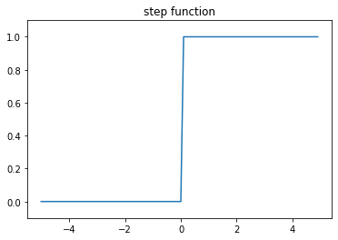

```python
X = np.arange(-5.0, 5.0, 0.1)
Y = step_function(X)
plt.plot(X, Y)
plt.ylim(-0.1, 1.1)  # 図で描画するy軸の範囲を指定
plt.title("step function")
plt.show()
```

## シグモイド関数

```python
def sigmoid(x):
    return 1 / (1 + np.exp(-x))
```

このxはnumpy配列も対応している  
numpyのブロードキャストのおかげ。

```python
x = np.array([-1, 1, 2])
```

```python
sigmoid(x)
```

```
array([0.26894142, 0.73105858, 0.88079708])
```

グラフ

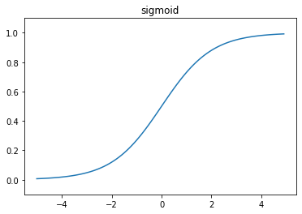

```python
X = np.arange(-5.0, 5.0, 0.1)
Y = sigmoid(X)
plt.plot(X, Y)
plt.ylim(-0.1, 1.1)
plt.title("sigmoid")
plt.show()
```

↑ ステップ関数に比べ、なめらかさがでている  
両者ともに、非線形関数。  
線形関数ではダメ。

### 両者の比較

/Users/yamada/machine-learning/deep-learning-from-scratch/ch03/sig_step_compare.py

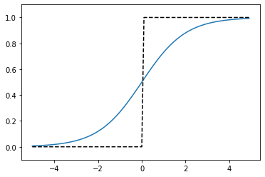

```python
def sigmoid(x):
    return 1 / (1 + np.exp(-x))


def step_function(x):
    return np.array(x > 0, dtype=np.int)

x = np.arange(-5.0, 5.0, 0.1)
y1 = sigmoid(x)
y2 = step_function(x)

plt.plot(x, y1)
plt.plot(x, y2, 'k--')
plt.ylim(-0.1, 1.1) #図で描画するy軸の範囲を指定
plt.show()
```

## ReLU関数

sigmoidより最近の主流。

```python
def relu(x):
    return np.maximum(0, x)
```

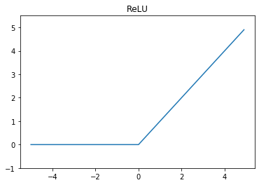

```python
x = np.arange(-5.0, 5.0, 0.1)
y = relu(x)
plt.plot(x, y)
plt.ylim(-1.0, 5.5)
plt.title("ReLU")
plt.show()
```

## 多次元配列の計算

行列の計算

```python
x = np.array([[1, 2], [3, 4], [5, 6]])
```

```python
x
```

```
array([[1, 2],
       [3, 4],
       [5, 6]])
```

```python
# 次元数
np.ndim(x)
```

```
2
```

```python
# 何行何列
x.shape
```

```
(3, 2)
```

```python
# 転置
y = x.T
```

```python
y
```

```
array([[1, 3, 5],
       [2, 4, 6]])
```

```python
# 積
np.dot(x, y)
```

```
array([[ 5, 11, 17],
       [11, 25, 39],
       [17, 39, 61]])
```

```python
# 逆ver
np.dot(y, x)
```

```
array([[35, 44],
       [44, 56]])
```

↓ ニューラルネットワークの行列の積も、これで一度にたくさん計算できる

[figure not shown]

```python
x = np.array([1, 2])
w = np.array([[1, 3, 5], [2, 4, 6]])
```

```python
y = np.dot(x, w)
```

```python
y
```

```
array([ 5, 11, 17])
```

## 3層ニューラルネットワークの実装

[figure not shown]

### まずa1の層に伝わる値を計算する

```python
X = np.array([1.0, 0.5])
W1 = np.array([[0.1, 0.3, 0.5], [0.2, 0.4, 0.6]])
B1 = np.array([0.1, 0.2, 0.3])
```

```python
print(W1.shape)
print(X.shape)
print(B1.shape)
```

```
(2, 3)
(2,)
(3,)
```

```python
A1 = np.dot(X, W1) + B1
```

```python
A1
```

```
array([0.3, 0.7, 1.1])
```

### 第1層目の活性化関数

[figure not shown]

シグモイド関数を使う

```python
Z1 = sigmoid(A1)
```

```python
Z1
```

```
array([0.57444252, 0.66818777, 0.75026011])
```

### 第1層目→第2層目

```python
W2 = np.array([[0.1, 0.4], [0.2, 0.5], [0.3, 0.6]])
B2 = np.array([0.1, 0.2])
```

```python
A2 = np.dot(Z1, W2) + B2
Z2 = sigmoid(A2)
```

```python
Z2
```

```
array([0.62624937, 0.7710107 ])
```

### 第2層目→出力層

```python
def identify_function(x):
    return x
```

```python
W3 = np.array([[0.1, 0.3], [0.2, 0.4]])
B3 = np.array([0.1, 0.2])
```

```python
A3 = np.dot(Z2, W3) + B3
Y = identify_function(A3)
```

```python
Y
```

```
array([0.31682708, 0.69627909])
```

### まとめ

```python
def init_network():
    network = {}
    network['W1'] = np.array([[0.1, 0.3, 0.5], [0.2, 0.4, 0.6]])
    network['b1'] = np.array([0.1, 0.2, 0.3])
    network['W2'] = np.array([[0.1, 0.4], [0.2, 0.5], [0.3, 0.6]])
    network['b2'] = np.array([0.1, 0.2])
    network['W3'] = np.array([[0.1, 0.3], [0.2, 0.4]])
    network['b3'] = np.array([0.1, 0.2])

    return network
```

```python
init_network()
```

```
{'W1': array([[0.1, 0.3, 0.5],
        [0.2, 0.4, 0.6]]),
 'b1': array([0.1, 0.2, 0.3]),
 'W2': array([[0.1, 0.4],
        [0.2, 0.5],
        [0.3, 0.6]]),
 'b2': array([0.1, 0.2]),
 'W3': array([[0.1, 0.3],
        [0.2, 0.4]]),
 'b3': array([0.1, 0.2])}
```

```python
def forward(network, x):
    W1, W2, W3 = network['W1'], network['W2'], network['W3']
    b1, b2, b3 = network['b1'], network['b2'], network['b3']

    a1 = np.dot(x, W1) + b1
    z1 = sigmoid(a1)
    a2 = np.dot(z1, W2) + b2
    z2 = sigmoid(a2)
    a3 = np.dot(z2, W3) + b3
    y = identify_function(a3)

    return y
```

実行

```python
network = init_network()
x = np.array([1.0, 0.5])
y = forward(network, x)
```

```python
print(y)
```

```
[0.31682708 0.69627909]
```

## 出力層の設計

ニューラルネットワーク→分類問題or回帰問題

- 回帰分類：恒等関数
- 分類問題：ソフトマックス関数

### 恒等関数

入力をそのまま出力する

[figure not shown]

### ソフトマックス関数

[figure not shown]

#### 実装

```python
a = np.array([0.3, 2.9, 4.0])
exp_a = np.exp(a)
```

```python
print(exp_a)
```

```
[ 1.34985881 18.17414537 54.59815003]
```

```python
sum_exp_a = np.sum(exp_a)
```

```python
print(sum_exp_a)
```

```
74.1221542101633
```

```python
y = exp_a / sum_exp_a
print(y)
```

```
[0.01821127 0.24519181 0.73659691]
```

```python
# 定義
def softmax(a):
    exp_a = np.exp(a)
    sum_exp_a = np.sum(exp_a)
    y = exp_a / sum_exp_a

    return y
```

↑ この実装の欠陥：オーバーフローになること。(指数関数の値がすぐ大きくなってしまうため)

```python
softmax([1010, 1000, 900])
```

```
array([nan, nan, nan])
```

nan = not a number

- 対策

定数を足しても値は変わらない

[figure not shown]

```python
# オーバーフロー対策
def softmax(a):
    c = np.max(a)
    exp_a = np.exp(a - c) # オーバーフロー対策
    sum_exp_a = np.sum(exp_a)
    y = exp_a / sum_exp_a

    return y
```

```python
softmax([1010, 1000, 900])
```

```
array([9.99954602e-01, 4.53978687e-05, 1.68883521e-48])
```

計算できる！

```python
# ソフトマックス関数の総和は、1
sum(softmax([1010, 1000, 900]))
```

```
1.0
```

↓

ソフトマックス関数の出力を、「確率」として捉えることができる

### 代表的な活性化関数 まとめ

[初心者の初心者による初心者のためのニューラルネットワーク#2〜理論 ：誤差計算編〜 - Qiita](https://qiita.com/sakigakeman/items/44af9ffde0550e52495e)

[figure not shown]

## 実践：手書き文字認識

MNISTデータを使う

### データの準備

/Users/yamada/machine-learning/deep-learning-from-scratch/dataset/mnist.py  
を使う

使用は、ch0*ディレクトリのいずれか

```python
# 移動
%cd ch03
```

```
/Users/yamada/machine-learning/deep-learning-from-scratch/ch03
```

```python
!pwd
```

```
/Users/yamada/machine-learning/deep-learning-from-scratch/ch03
```

```python
try:
    import urllib.request
except ImportError:
    raise ImportError('You should use Python 3.x')
import os.path
import gzip
import pickle
import os
import numpy as np
```

```python
import sys, os
sys.path.append(os.pardir) # 親ディレクトリのファイルをインポートするための設定
from dataset.mnist import load_mnist
```

(訓練画像, 訓練ラベル), (テスト画像, テストラベル)

```python
# 最初の呼び出しは時間かかる
(x_train, t_train), (x_test, t_test) = \
load_mnist(flatten=True, normalize=False)
```

```
Downloading train-images-idx3-ubyte.gz ...
Done
Downloading train-labels-idx1-ubyte.gz ...
Done
Downloading t10k-images-idx3-ubyte.gz ...
Done
Downloading t10k-labels-idx1-ubyte.gz ...
Done
Converting train-images-idx3-ubyte.gz to NumPy Array ...
Done
Converting train-labels-idx1-ubyte.gz to NumPy Array ...
Done
Converting t10k-images-idx3-ubyte.gz to NumPy Array ...
Done
Converting t10k-labels-idx1-ubyte.gz to NumPy Array ...
Done
Creating pickle file ...
Done!
```

データの準備には、pickleを使っているそう

### データの確認

```python
%cd ..
```

```
/Users/yamada/machine-learning/deep-learning-from-scratch
```

/Users/yamada/machine-learning/deep-learning-from-scratch/ch03/mnist_show.py

```python
from PIL import Image


def img_show(img):
    pil_img = Image.fromarray(np.uint8(img))
    pil_img.show()

(x_train, t_train), (x_test, t_test) = load_mnist(flatten=True, normalize=False)

img = x_train[0]
label = t_train[0]
print(label)  # 5

print(img.shape)  # (784,)
img = img.reshape(28, 28)  # 形状を元の画像サイズに変形
print(img.shape)  # (28, 28)

img_show(img)
```

```
5
(784,)
(28, 28)
```

[figure not shown]

### ニューラルネットワークの推論処理

入力層784個、出力層10個

- 784 = 28*28(画像のサイズ)
- 10クラス分類

2つの隠れ層

- 1つめの隠れ層：50個
- 2つめ：100個

/Users/yamada/machine-learning/deep-learning-from-scratch/ch03/neuralnet_mnist.py

```python
%cd ch03
```

```
/Users/yamada/machine-learning/deep-learning-from-scratch/ch03
```

```python
import sys, os
sys.path.append(os.pardir)  # 親ディレクトリのファイルをインポートするための設定
import numpy as np
import pickle
from dataset.mnist import load_mnist
from common.functions import sigmoid, softmax
```

```python
def get_data():
    (x_train, t_train), (x_test, t_test) = load_mnist(normalize=True, flatten=True, one_hot_label=False)
    return x_test, t_test
```

```python
def init_network():
    with open("sample_weight.pkl", 'rb') as f:
        network = pickle.load(f)
    return network
```

```python
def predict(network, x):
    w1, w2, w3 = network['W1'], network['W2'], network['W3']
    b1, b2, b3 = network['b1'], network['b2'], network['b3']

    a1 = np.dot(x, w1) + b1
    z1 = sigmoid(a1)
    a2 = np.dot(z1, w2) + b2
    z2 = sigmoid(a2)
    a3 = np.dot(z2, w3) + b3
    y = softmax(a3)

    return y
```

実行

```python
x, t = get_data()
network = init_network()
accuracy_cnt = 0
for i in range(len(x)):
    y = predict(network, x[i])
    p= np.argmax(y) # 最も確率の高い要素のインデックスを取得
    # 正解ラベルと一致していたら、1加算
    if p == t[i]:
        accuracy_cnt += 1

print("Accuracy:" + str(float(accuracy_cnt) / len(x)))
```

```
Accuracy:0.9352
```

### 変数の確認

- network:学習済みの重みとバイアスのパラメータが辞書形式で入っている

[figure not shown]

- y_batchは、predictの結果。各ラベルの確率がnumpy配列として入っている。

[figure not shown]

- p = np.argmax(y_batch, axis=1)は、y_batchの10個の確率のうち、どれがもっとも高い数字か、最大値のインデックスを取得

```python
print(p)
```

[output not shown]

#### 正規化

画像の各ピクセルの値を255で割って、データの値が0.0~1.0の範囲に収まるように変換

#### 白色化

データ全体の分布の形状を均一にする方法、なども。

#### 前処理

ニューラルネットワークの入力データに対して、何らかの決まった変換を行うこと

### バッチ処理

上の実装の再確認

#### 画像1枚分の処理

```python
x, _ = get_data()
network = init_network()
W1, W2, W3 = network['W1'], network['W2'], network['W3']
```

```python
x.shape
```

```
(10000, 784)
```

```python
x[0].shape
```

```
(784,)
```

```python
W1.shape
```

```
(784, 50)
```

```python
W2.shape
```

```
(50, 100)
```

```python
W3.shape
```

```
(100, 10)
```

次元の要素数が段々と一致している  
最終的に、ラベル数の10に合致する

#### 画像をまとめて入力したい

- バッチ：まとまりのある入力データ

計算時間の速さ  
大きな配列を一度に計算する < 分割した小さい配列を少しずつ計算する

```python
x, t = get_data()
network = init_network()

batch_size = 100 # バッチの数
accuracy_cnt = 0

for i in range(0, len(x), batch_size):
    x_batch = x[i:i+batch_size]
    y_batch = predict(network, x_batch)
    p = np.argmax(y_batch, axis=1)
    accuracy_cnt += np.sum(p == t[i:i+batch_size])

print("Accuracy:" + str(float(accuracy_cnt) / len(x)))
```

```
Accuracy:0.9352
```

np.argmax()のちがい

```python
np.argmax(y_batch)
```

```
86
```

```python
np.argmax(y_batch, axis=1)
```

```
array([8, 9, 0, 1, 2, 9, 4, 5, 6, 7, 8, 0, 1, 2, 3, 4, 7, 8, 9, 7, 8, 6,
       4, 1, 9, 2, 8, 4, 4, 7, 0, 1, 9, 2, 8, 7, 8, 2, 6, 0, 0, 6, 3, 5,
       9, 9, 1, 4, 0, 6, 1, 0, 0, 6, 2, 1, 1, 7, 7, 8, 4, 6, 0, 7, 0, 3,
       6, 8, 7, 1, 3, 2, 4, 9, 4, 3, 6, 4, 1, 7, 2, 6, 2, 0, 1, 2, 8, 4,
       5, 6, 7, 8, 9, 0, 1, 2, 3, 4, 5, 6])
```